[figure not shown]

This report tracks the IRC M&E indicators for the ReBuild studies across both countries and various data collection rounds. KPIs and indicators are shown for mentees only. KPI 1.1 shows the numbers of enrolled mentors, but mentors are not included in any other subsequent KPI or indicator.

# Section 1: Client Service Delivery Indicators

## KPI 1: Client placement

### Group assignment

The tables below show the assignment to each arm in the studies. They include people who subsequently dropped out and ended up being not treated (or served) by the IRC.

[output not shown]

[output not shown]

## Compliance and attrition

The graphs below present the clients split into three groups, relevant for IRC’s monitoring team: (1) treated clients (assigned to one of the three active treatment arms, and effectively served), (2) untreated clients (assigned to one of the three active treatment arms, but not served by the IRC for lack of compliance or follow through), (3) control clients (assigned to control group at randomization).

It is important to keep these overal sample sizes in mind as we breakdown the analyses below for these three groups; in particular, the untreated group (2) is rather small, especially when broken down by demographics. Large variation in the untreated group may then often be attributed to noise as opposed to a statistically significant difference with the other clients.

**Uganda (by demographics)**

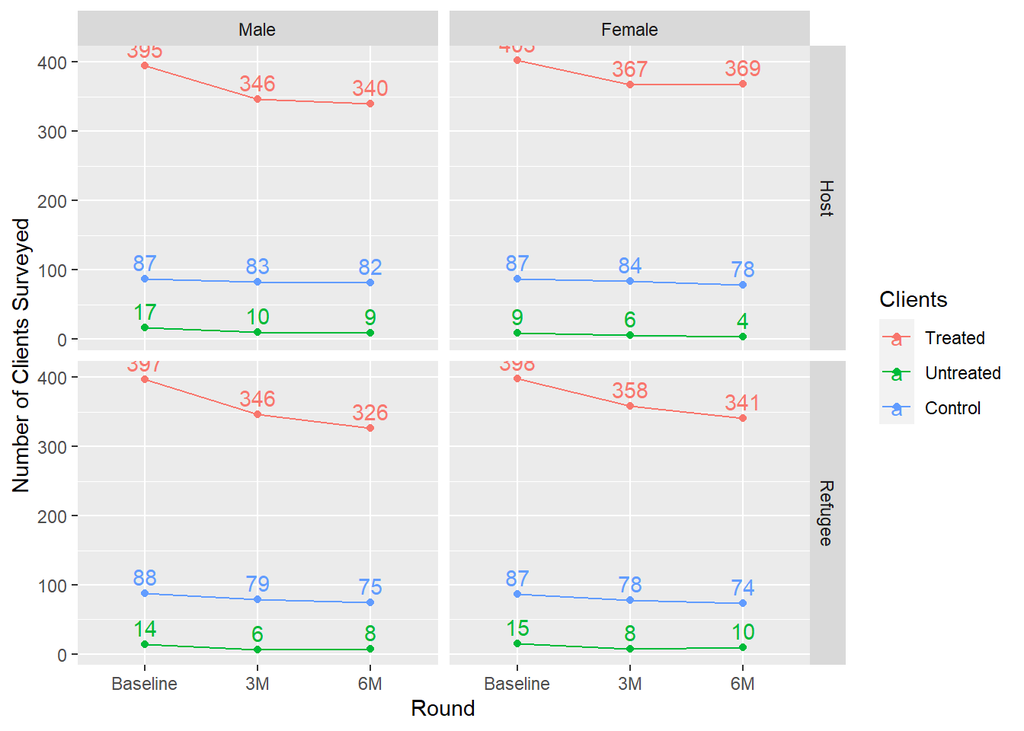

**Uganda (all)**

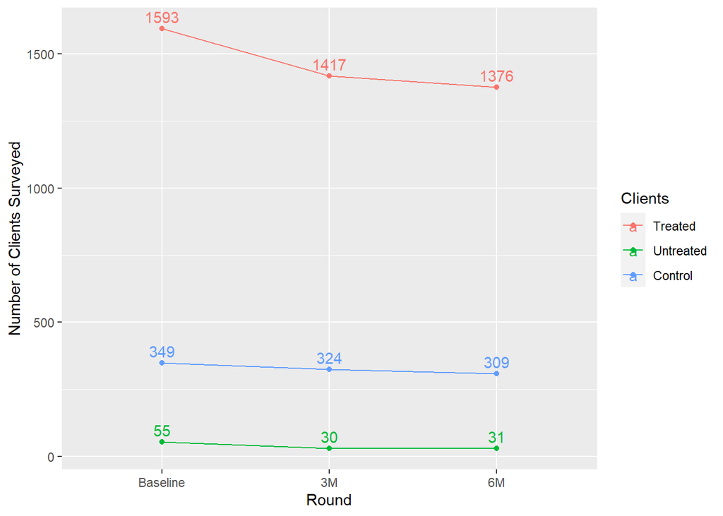

**Kenya (by demographics)**

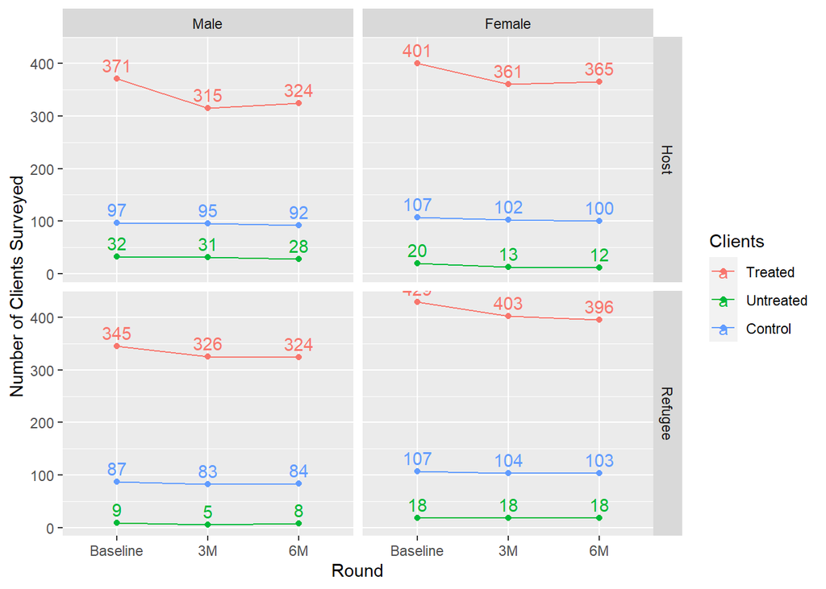

**Kenya (all)**

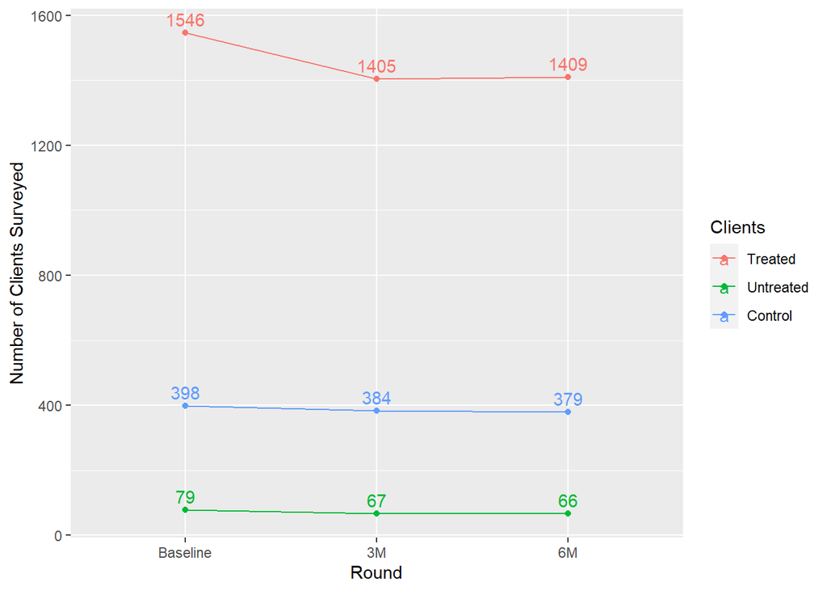

## KPI 2: Earned income (wages and salaries)

The self-reported income data collected from respondents consists of income earned from wages or salaries over the last 30 days from different forms of employment and are denoted in USD. They do not include income from self employment (nor business profits).

### Proportion of increases compared to baseline

The “increase in income” estimates compare the income in a given round to the income at baseline. The KPI shows the proportion of participants whose wage income has increased since baseline.

**Uganda (by demographics)**

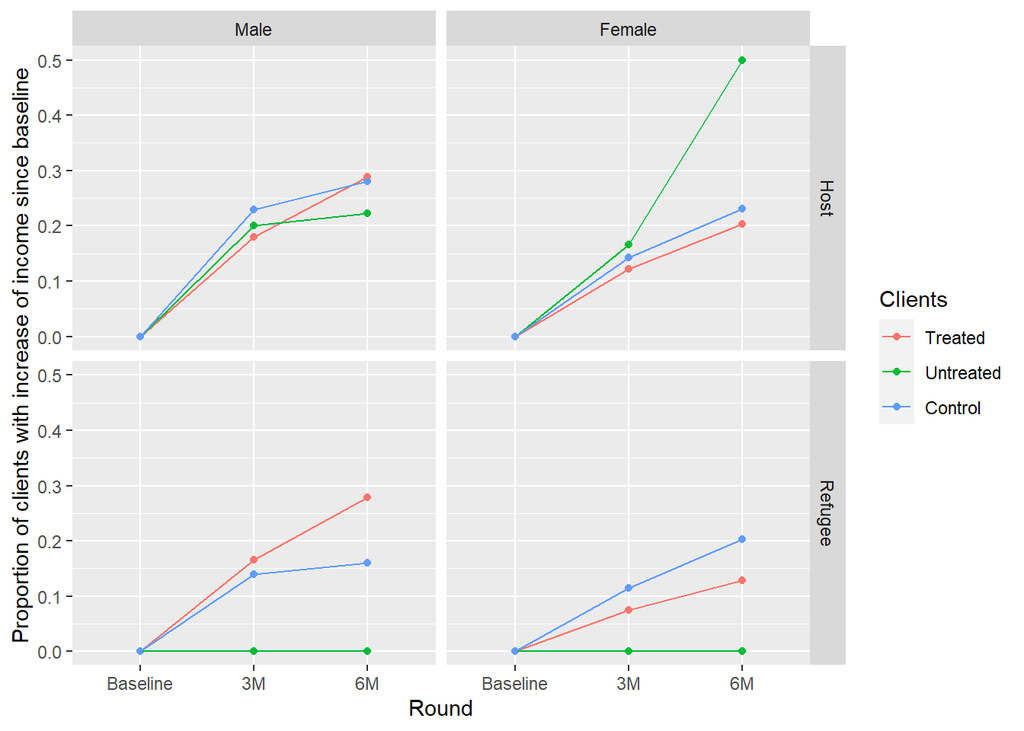

**Uganda (all)**

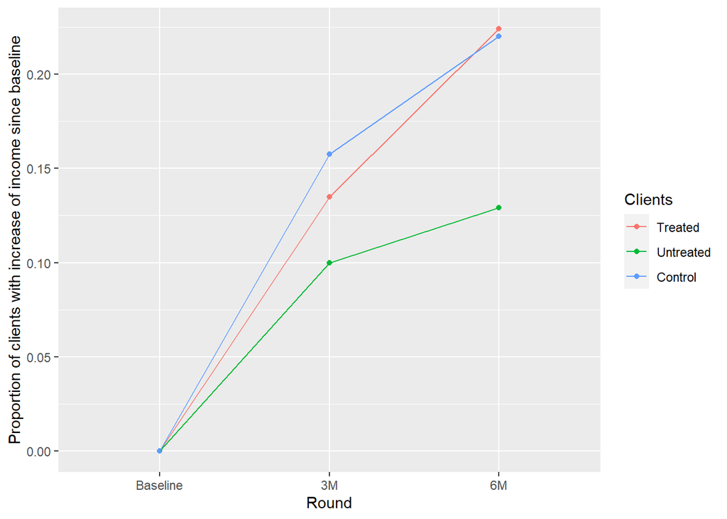

**Kenya (by demographics)**

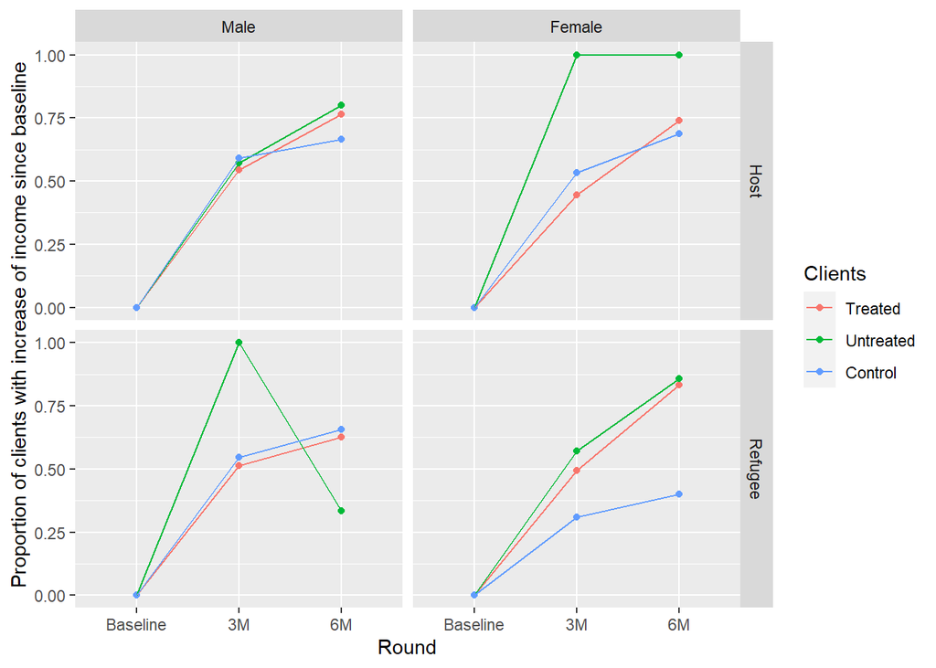

**Kenya (all)**

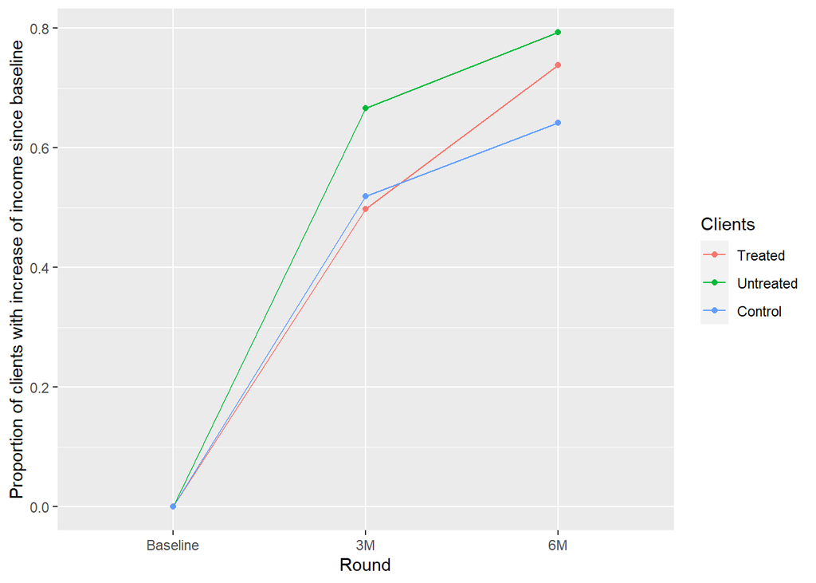

### Level of income

The wage income is represented in dollars (and winsorised at the 1st and 99th percentiles) in any given round.

**Uganda (by demographics)**

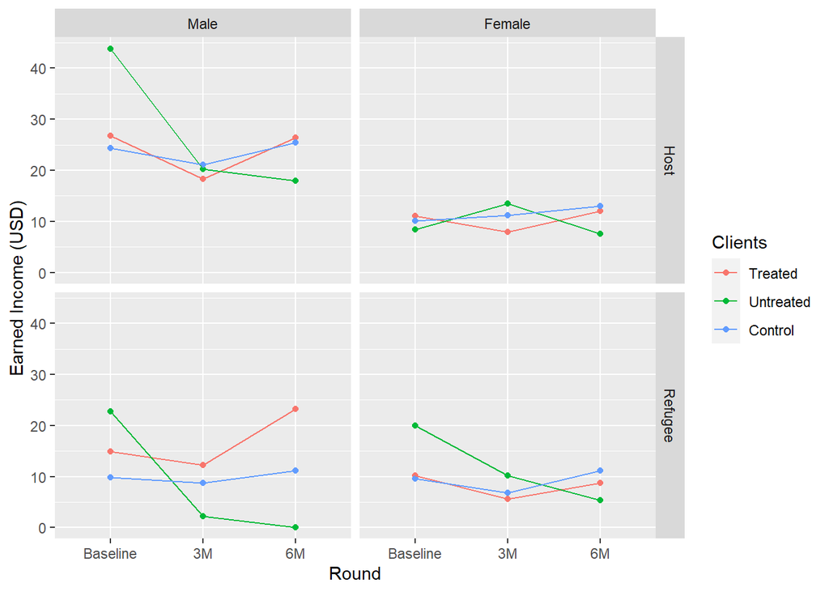

**Uganda (all)**

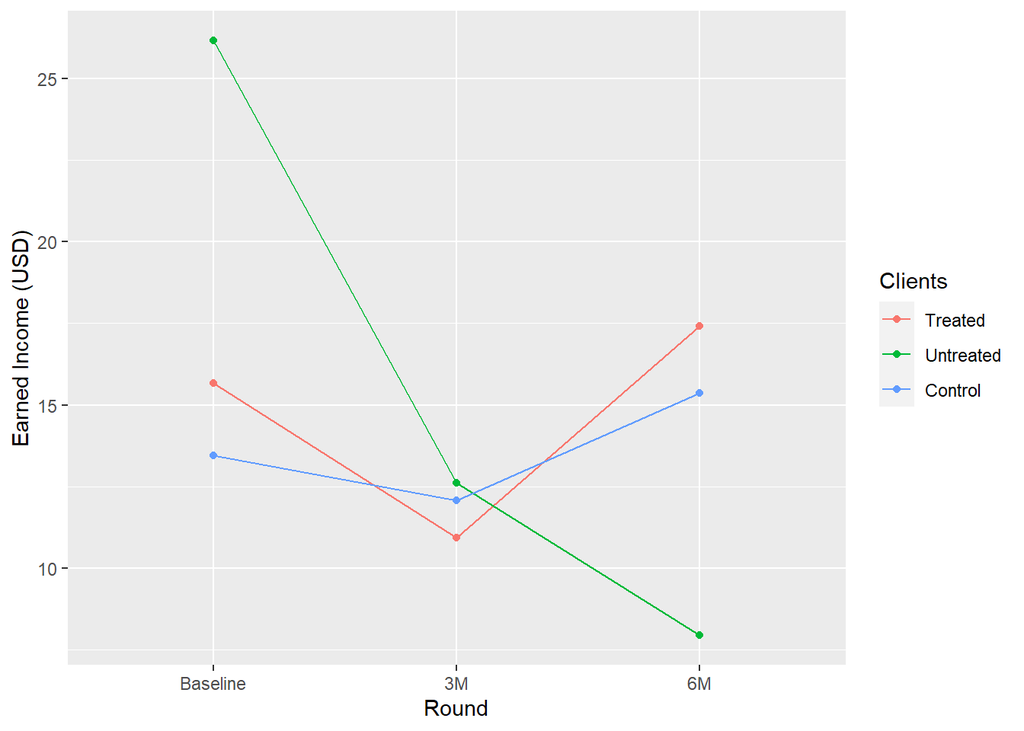

**Kenya (by demographics)**

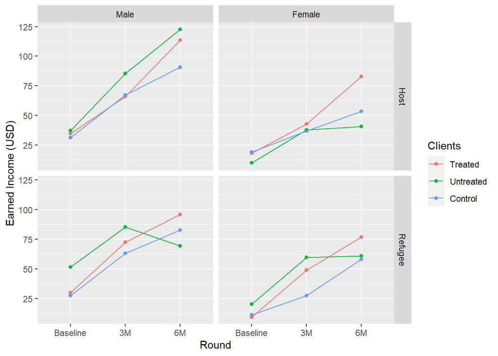

**Kenya (all)**

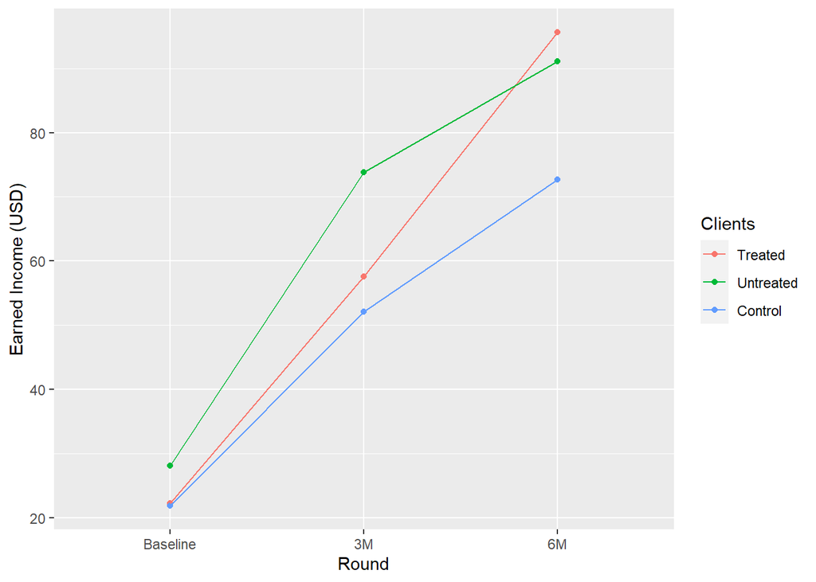

## KPI 3: Business Status

The data collected for this KPI is from survey data where the respondent is asked whether or not they currently own or operate a business at the time of data collection. Across all survey rounds breakdowns are provided of who own a business and those that do not own a business. This combines new and old businesses.

**Uganda (by demographics)**

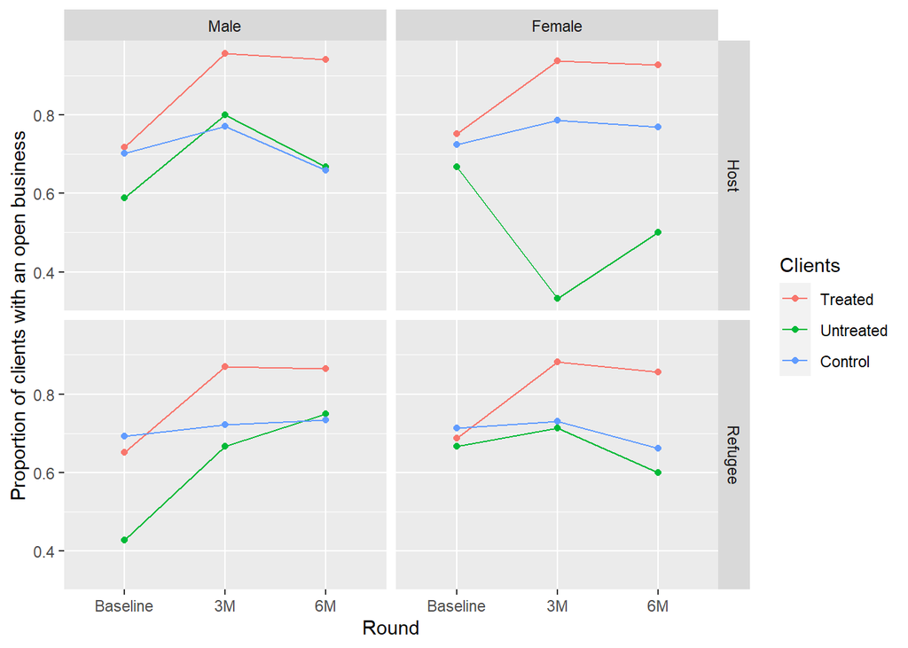

**Uganda (all)**

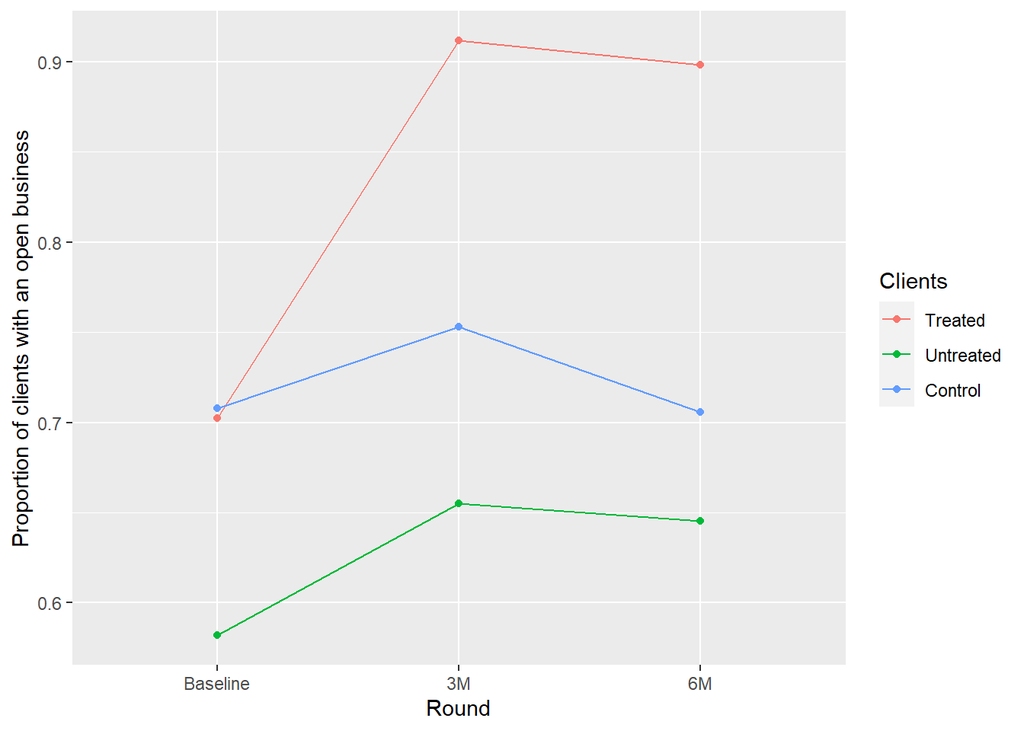

**Kenya (by demographics)**

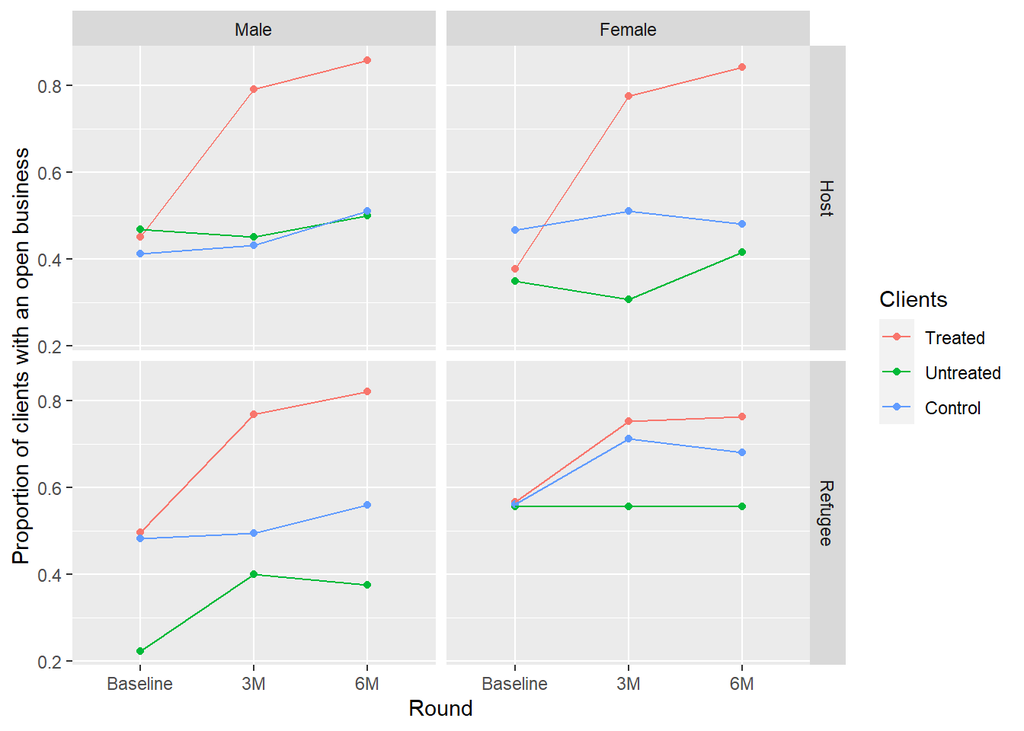

**Kenya (all)**

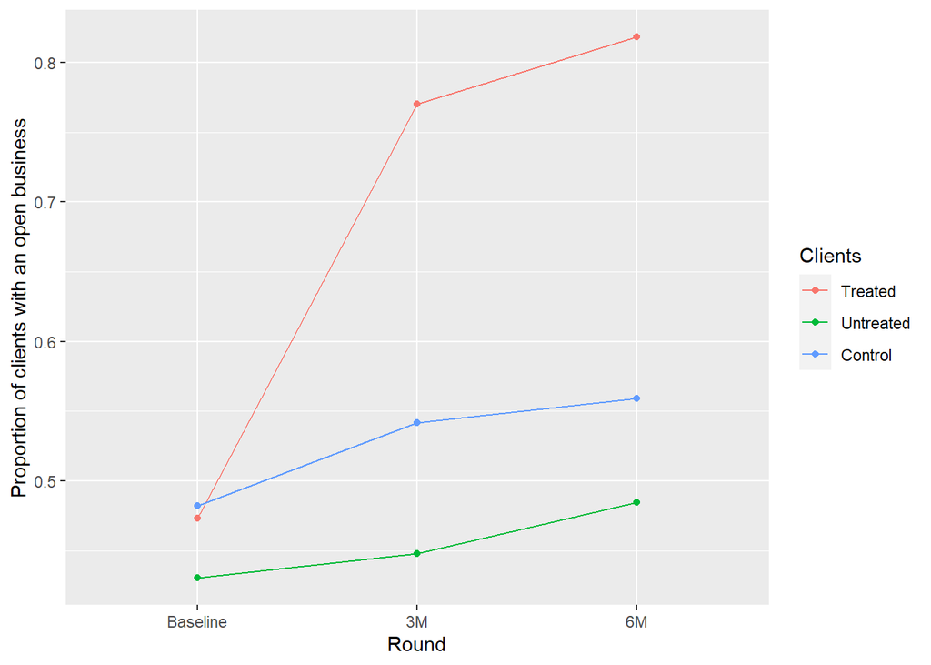

## KPI 4: Time Spent Working

In Uganda, working time is captured as number of hours worked in the past 7 days. In Kenya, working time is captured as number of days worked in the past 30 days.

### Proportion of clients working 40% or more of the time

This KPI reports the proportion of clients who work at least 16 hours in the last 7 days (about 40% of the time, assuming a full work week is 40 hours) in Uganda, and the proportion of clients who work at least 8 days in the last 30 days (about 40% of the time, excluding weekends from working days) in Kenya.

**Uganda (by demographics)**

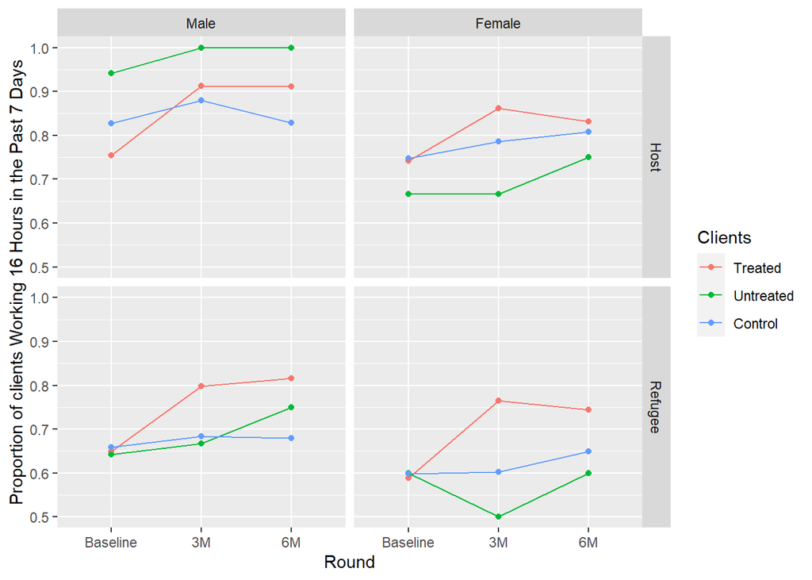

**Uganda (all)**

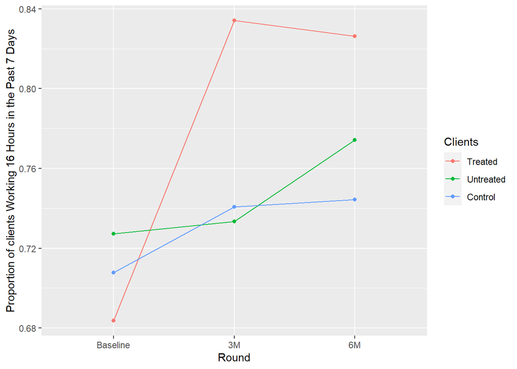

**Kenya (by demographics)**

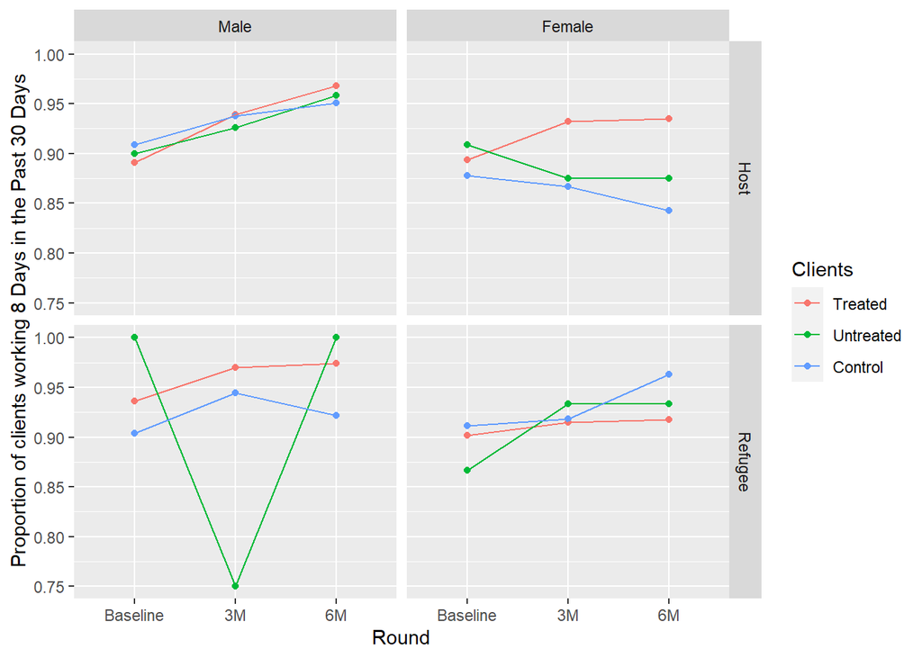

**Kenya (all)**

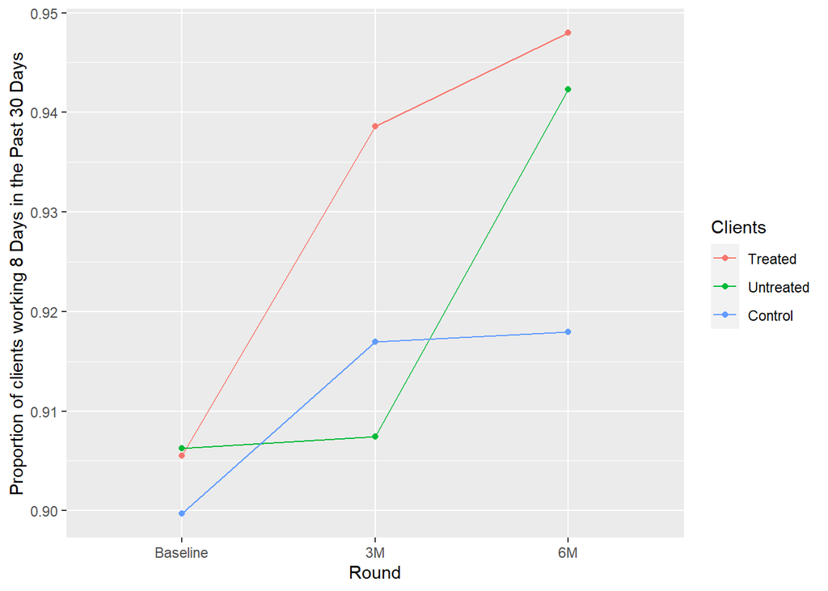

### Amount of time spent working

**Uganda (by demographics)**

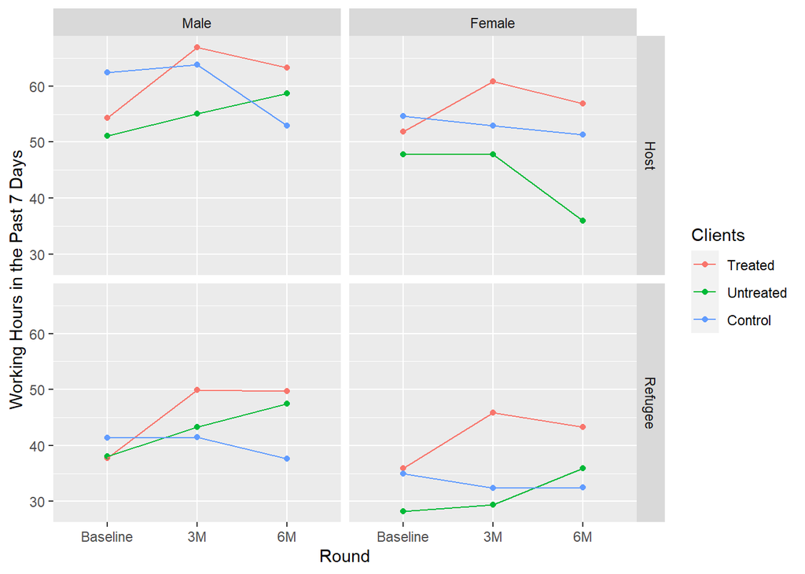

**Uganda (all)**

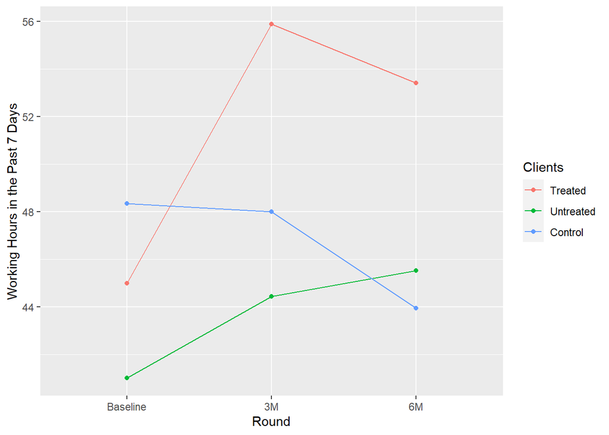

**Kenya (by demographics)**

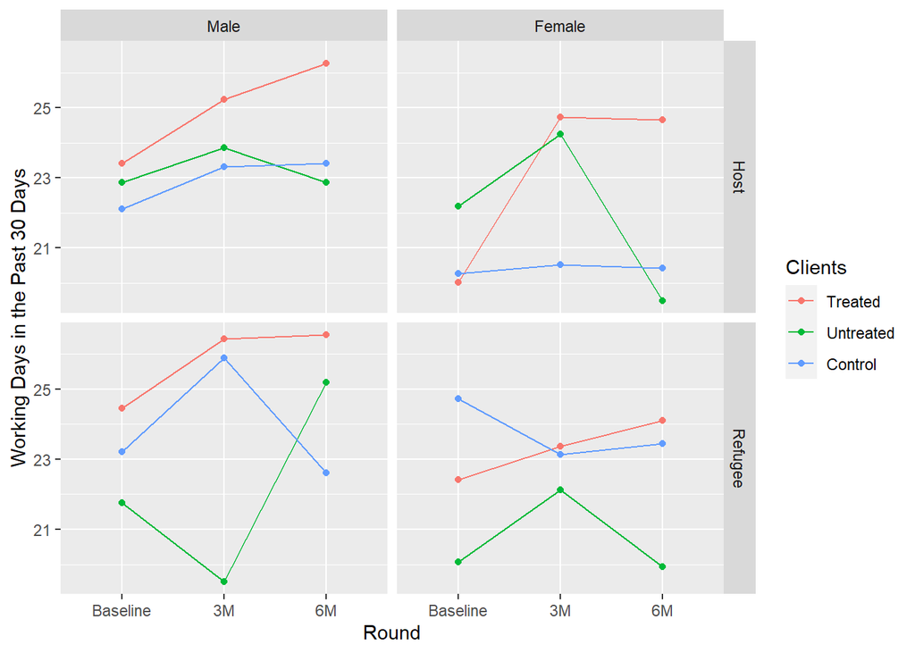

**Kenya (all)**

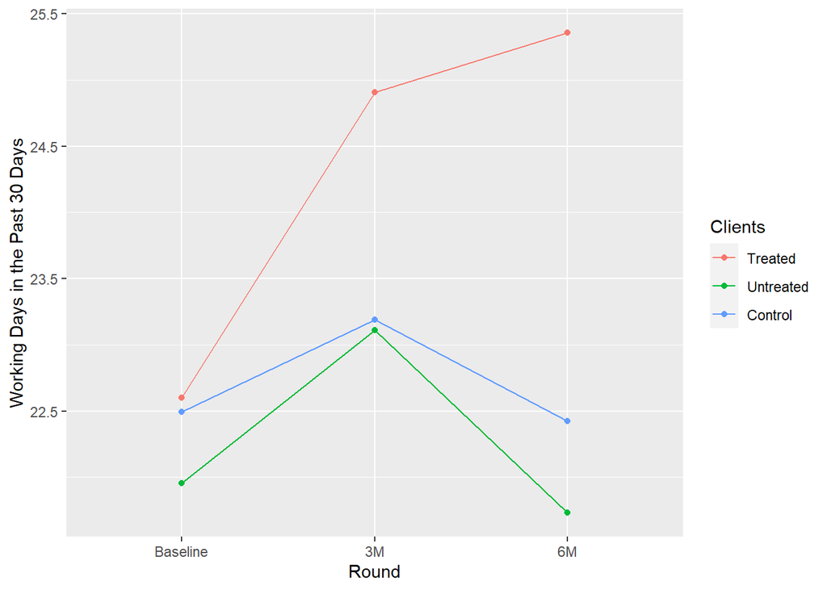

# Section 2: Economic Well-Being Indicators

## EWB.018: Self-Reported Business Profits (Main)

Profits of the client’s main business in the past 30 days, converted to USD and winsorised at the 1st and 99th percentiles.

**Uganda (by demographics)**

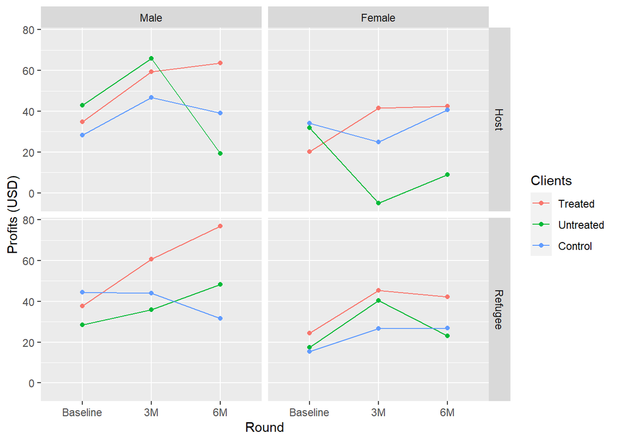

**Uganda (all)**

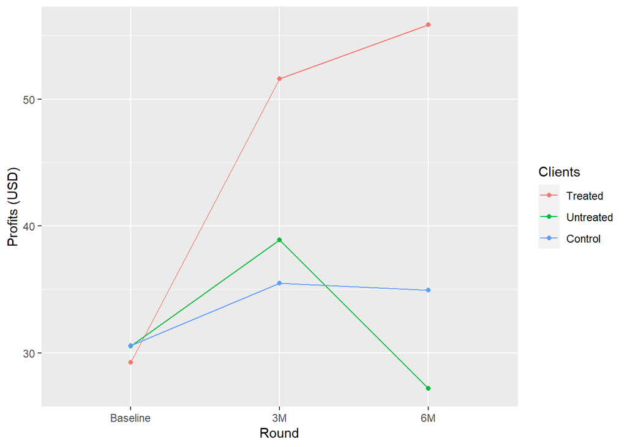

**Kenya (by demographics)**

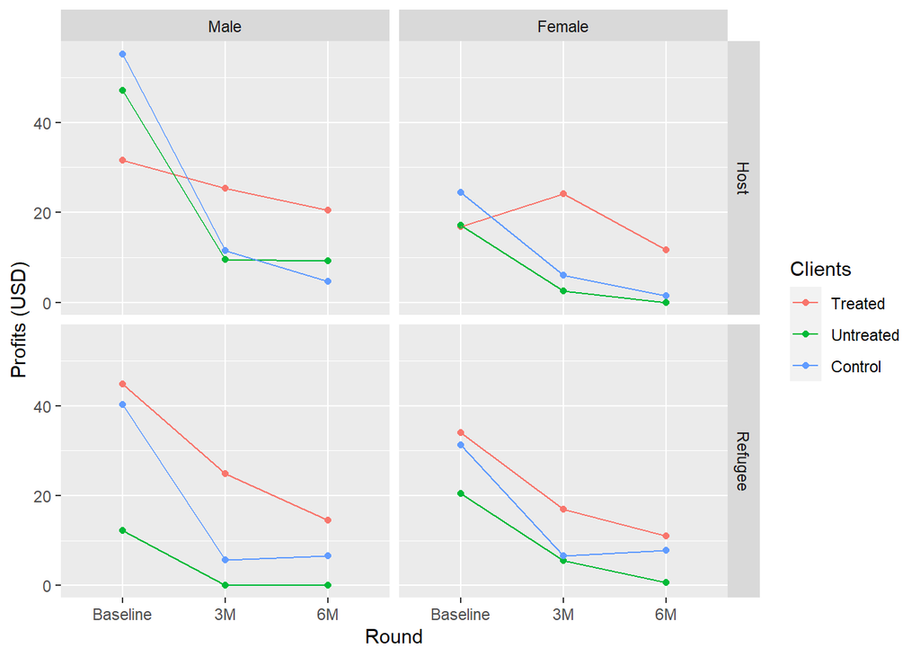

**Kenya (all)**

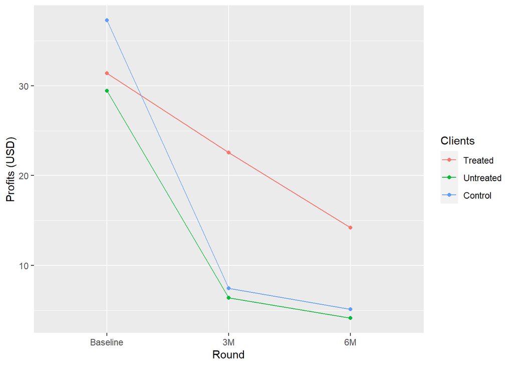